# Rice price project — data sanity checks

2026-11-13

# Decisions taken after these checks (2026-11-13)

| Decision | Choice | Why (section) |
| --- | --- | --- |
| Sample window | **Sep 2010 → latest, for all models** | Monthly X1 doesn’t exist before then (3); one window keeps the models comparable |
| Intervention dummies | Shortage regime from Aug 2024 only. **No Jan 2007 / Jan 2012 dummies** | Item 1001 had no spec revision then (2.1) |
| Evaluation | Last-12-month holdout **plus** rolling-window ASE: 96-month training window, step 1, h = 3 and 12, split by origin before/after Aug 2024 | The holdout sits entirely inside the turn (7.3). A 96-month window gives 72 pre-break origins at each horizon |
| Weather | Add **Niigata Jun–Aug precipitation, % of the 1991–2020 normal** (X3b). Anomalies use JMA’s official normals | Aug 2023 was both the hottest and the driest August (5, 5b) |
| Latest X1 month | Re-pull MAFF when the Oct 2026 release appears, before modelling | Sep 2026 is thin and preliminary (3.4) |

The model-ready data that implements these decisions is `data/processed/model_data.csv` with `splits.rds` (built by `R/20_prepare_model_data.R`).

This report checks the raw data against the assumptions in `spec.md` before any EDA or modelling. Raw files are in `data/raw/` (see `data/README.md`). The parsed and joined table is `data/interim/monthly.csv`, which is **tax-inclusive and untransformed**. Each section ends with a pass, flag or fail result, and the summary gathers them into a go/revise call.

# 1. Coverage

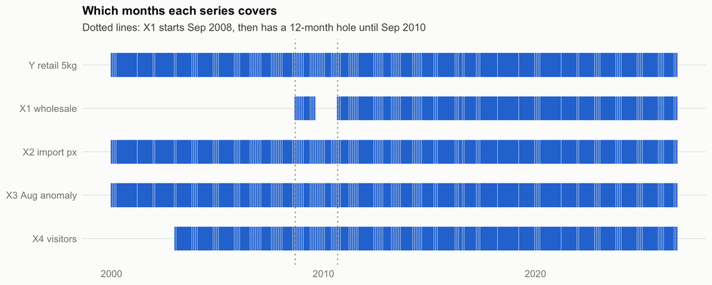

```r
series <- c(y = "Y retail 5kg", x1 = "X1 wholesale", x2_all = "X2 import px", x3 = "X3 Aug anomaly", x4 = "X4 visitors")
cov <- m |> select(date, all_of(names(series))) |> pivot_longer(-date) |>
  mutate(present = !is.na(value), name = factor(series[name], rev(series)))
ggplot(cov |> filter(present), aes(date, name)) +
  geom_tile(fill = pal["blue"], height = 0.55) +
  geom_vline(xintercept = as.Date(c("2008-09-01", "2010-09-01")), colour = muted, linetype = 3) +
  labs(x = NULL, y = NULL, title = "Which months each series covers",
       subtitle = "Dotted lines: X1 starts Sep 2008, then has a 12-month hole until Sep 2010")
```

```r
cov |> group_by(Series = name) |>
  summarise(First = format(min(date[present]), "%Y-%m"), Last = format(max(date[present]), "%Y-%m"),
            Months = sum(present),
            `Gaps inside span` = sum(!present & date > min(date[present]) & date < max(date[present]))) |>
  arrange(desc(Series)) |> kable()
```

| Series | First | Last | Months | Gaps inside span |
| --- | --- | --- | --- | --- |
| Y retail 5kg | 2000-01 | 2026-09 | 321 | 0 |
| X1 wholesale | 2008-09 | 2026-09 | 205 | 12 |
| X2 import px | 2000-01 | 2026-09 | 321 | 0 |
| X3 Aug anomaly | 2000-01 | 2026-09 | 321 | 0 |
| X4 visitors | 2003-01 | 2026-09 | 285 | 0 |

```r
common <- m |> filter(!is.na(y), !is.na(x1), !is.na(x2_all), !is.na(x3))
cont   <- m |> filter(date >= as.Date("2010-09-01"))
```

**Common window (Y, X1, X2 and X3 all present): 205 months.** The longest continuous run is **Sep 2010 → Sep 2026 (193 months)**. The spec expected about 320. This is driven entirely by X1 (section 3).

# 2. Y — retail price, item 1001, Tokyo ku-area

## 2.1 Specification history for item 1001

```r
f <- "data/raw/estat/shinkyu_meigara_2001_2026.xlsx"
hist <- bind_rows(lapply(excel_sheets(f), function(sh) {
  d <- as.data.frame(read_excel(f, sheet = sh, col_names = FALSE, .name_repair = "minimal"))
  d[] <- lapply(d, function(x) gsub("[\r\n]+", " ", as.character(x)))
  h <- d[grepl("^\\s*1001\\s*$", d[[1]]), , drop = FALSE]
  if (!nrow(h)) return(NULL)
  data.frame(Year = trimws(sh), `New spec` = h[[3]], `Old spec` = h[[4]], Unit = h[[5]], Month = h[[6]], check.names = FALSE)
}))
kable(hist)
```

| Year | New spec | Old spec | Unit | Month |
| --- | --- | --- | --- | --- |
| 2009年 | 国内産，精米，単一原料米（産地，品種及び産年が同一のもの），袋入り（５ｋｇ入り），「コシヒカリ」 | 国内産，精米，単一品種（産地，産年が同一のもの），袋入り（５ｋｇ入り），「コシヒカリ」 | １袋 | 11月 |
| 2002年 | 国内産，精米，単一品種（産地，産年が同一のもの），袋入り（５ｋｇ入り），「コシヒカリ」 | 国内産，精米，単一品種，「コシヒカリ」 | １０ｋｇ ↓ １袋 | １月 |

The Statistics Bureau’s old-vs-new specification tables cover 2001–2026 and list **only two revisions** to item 1001:

- **January 2002: the unit changed from 10 kg to a 5 kg bag.** e-Stat publishes 2000–2001 **per 10 kg** with no note. `10_parse_join.R` halves those 24 values and sets the flag `unit_10kg`. The window starts after 2002 anyway (see X1), so this only matters for the sensitivity fit.
- **November 2009: wording only** (単一品種 → 単一原料米, a labelling-law change). The table below checks for a level shift.
- **No revision in January 2007, January 2012 or January 2026** for this item. The spec’s dummies for 2007 and 2012 have no documented basis for item 1001. The January 2026 notice changed only the table layout.

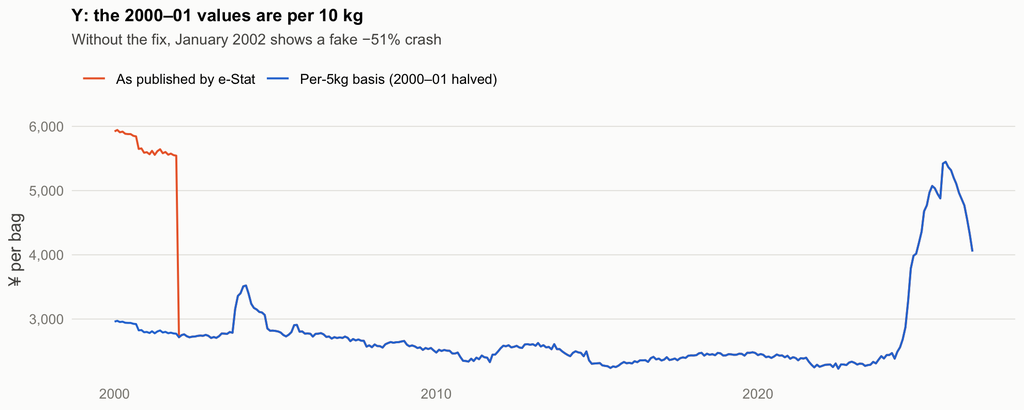

```r
ggplot(m, aes(date)) +
  geom_line(aes(y = y_raw, colour = "As published by e-Stat"), linewidth = 0.6) +
  geom_line(aes(y = y, colour = "Per-5kg basis (2000–01 halved)"), linewidth = 0.6) +
  scale_colour_manual(values = unname(pal[c("orange", "blue")])) +
  scale_y_continuous(labels = scales::comma) +
  labs(x = NULL, y = "¥ per bag", title = "Y: the 2000–01 values are per 10 kg",
       subtitle = "Without the fix, January 2002 shows a fake −51% crash")
```

```r
around <- function(d, k = 2) m |> mutate(dl = dlog(y)) |> filter(abs(as.numeric(date - as.Date(d))) <= 31 * k) |>
  transmute(Month = format(date, "%Y-%m"), `Y (¥)` = y, `Δlog Y` = round(dl, 3))
kable(around("2009-11-01"), caption = "Around the Nov 2009 wording change")
```

Around the Nov 2009 wording change

| Month | Y (¥) | Δlog Y |
| --- | --- | --- |
| 2009-09 | 2549 | 0.011 |
| 2009-10 | 2533 | -0.006 |
| 2009-11 | 2549 | 0.006 |
| 2009-12 | 2512 | -0.015 |
| 2010-01 | 2479 | -0.013 |